# Project: Investigate a Dataset - [Dataset-name]

```python
# Primero agrupamos los datos por 'director' y 'genres', y calculamos la suma de 'revenue_adj'
grouped = df.groupby(['director', 'genres'])['revenue_adj'].sum().unstack()

# Creamos el gráfico de columnas apiladas
grouped.plot(kind='bar', stacked=True)

# Mostramos el gráfico
plt.show()
```

[output not shown]

[output cut: 69 more lines]

[output not shown]

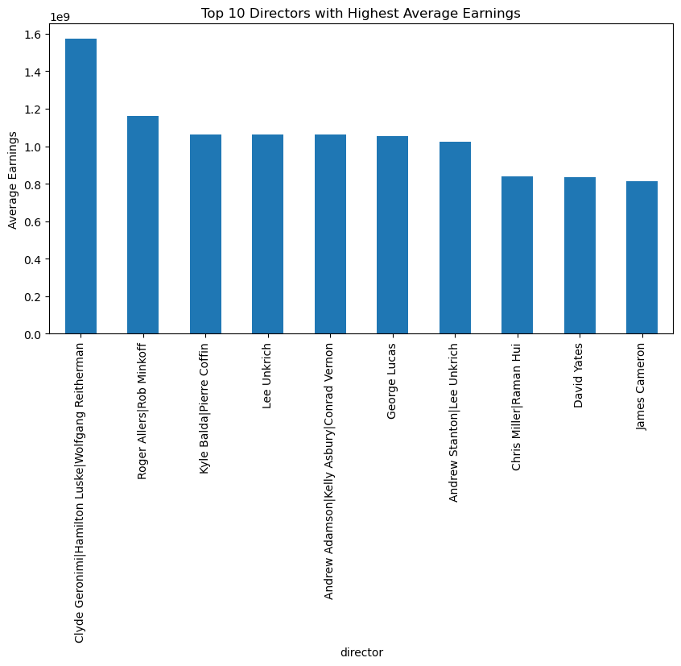

```python
# Calculate the average earnings per director
average_earnings = results['Total Earnings'] / results['Number of Movies']

# Add the averages to the results DataFrame
results['Average Earnings'] = average_earnings

# Create a visualization of the average earnings of each director
plt.figure(figsize=(10,5))
average_earnings.sort_values(ascending=False).head(10).plot(kind='bar')
plt.title('Top 10 Directors with Highest Average Earnings')
plt.ylabel('Average Earnings')
plt.show()
```

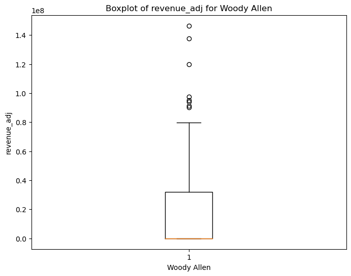

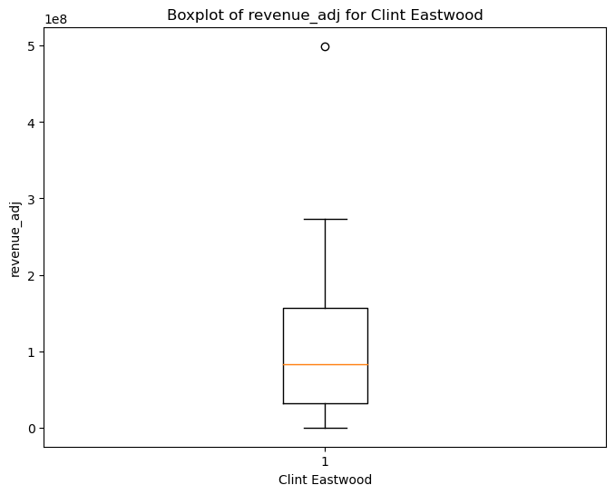

```python
# Plot a boxplot of revenue_adj for a specific director, for example, 'Christopher Nolan':
plot_boxplot_specific(df, 'director', 'revenue_adj', 'Woody Allen')
plot_boxplot_specific(df, 'director', 'revenue_adj', 'Clint Eastwood')
```

### Research Question 2 (Which has been the genre with the most films made and the highest profits?)

```python
# Continue to explore the data to address your additional research
#   questions. Add more headers as needed if you have more questions to
#   investigate.
```

```
Number of Movies    7.110000e+02
Total Earnings      2.090257e+10
Name: Drama, dtype: float64
```

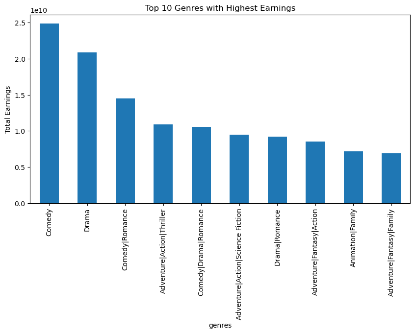

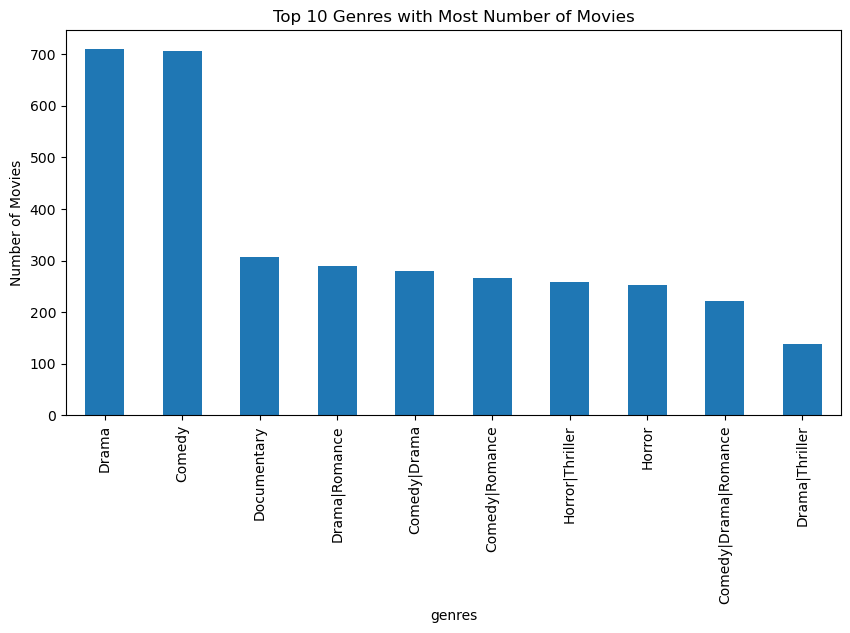

```python
# Group by genre and count the number of movies
num_movies = df.groupby('genres').size()

# Find the genre with the most movies
genre_most_movies = num_movies.idxmax()

# Group by genre and sum the earnings
genre_earnings = df.groupby('genres')['revenue_adj'].sum()

# Create a DataFrame with the results
results = pd.DataFrame({
    'Number of Movies': num_movies,
    'Total Earnings': genre_earnings
})

# Show the results for the genre with the most movies
print(results.loc[genre_most_movies])

# Create a visualization of the total earnings of each genre
plt.figure(figsize=(10,5))
genre_earnings.sort_values(ascending=False).head(10).plot(kind='bar')
plt.title('Top 10 Genres with Highest Earnings')
plt.ylabel('Total Earnings')
plt.show()

# Create a visualization of the number of movies of each genre
plt.figure(figsize=(10,5))
num_movies.sort_values(ascending=False).head(10).plot(kind='bar')
plt.title('Top 10 Genres with Most Number of Movies')
plt.ylabel('Number of Movies')
plt.show()
```

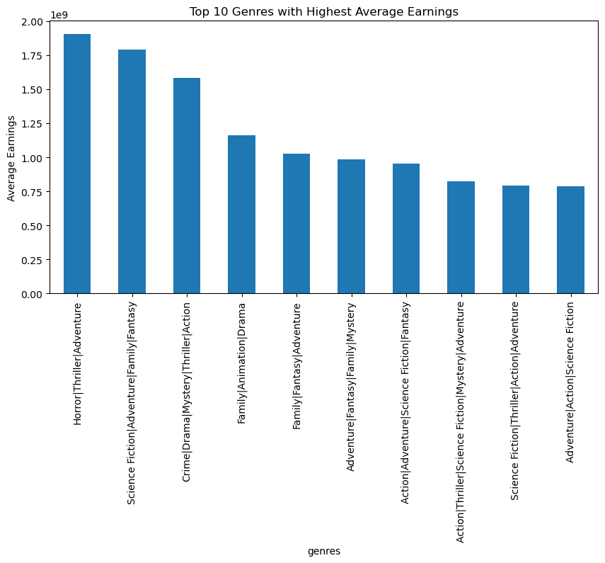

```python
# Calculate the average earnings per genre
average_earnings = results['Total Earnings'] / results['Number of Movies']

# Add the averages to the results DataFrame
results['Average Earnings'] = average_earnings

# Create a visualization of the average earnings of each genre
plt.figure(figsize=(10,5))
average_earnings.sort_values(ascending=False).head(10).plot(kind='bar')
plt.title('Top 10 Genres with Highest Average Earnings')
plt.ylabel('Average Earnings')
plt.show()
```

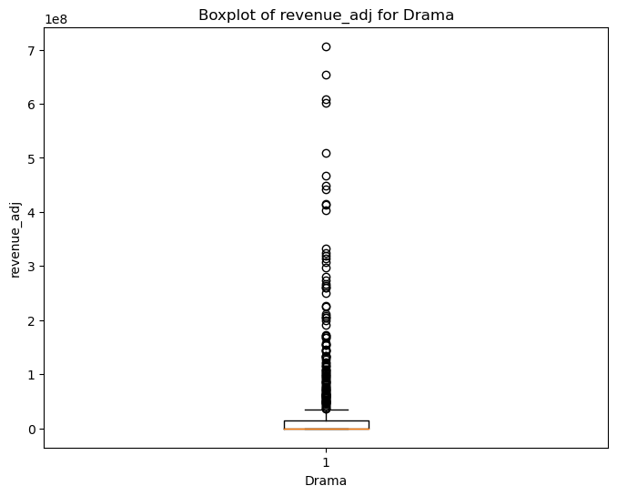

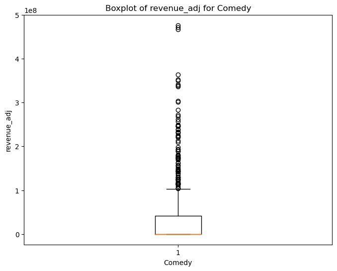

```python
# To plot a boxplot of revenue_adj for a specific genre, for example, 'Action':
plot_boxplot_specific(df, 'genres', 'revenue_adj', 'Drama')
plot_boxplot_specific(df, 'genres', 'revenue_adj', 'Comedy')
```

## Conclusions

> **Tip**: Finally, summarize your findings and the results that have been performed in relation to the question(s) provided at the beginning of the analysis. Summarize the results accurately, and point out where additional research can be done or where additional information could be useful.

> **Tip**: Make sure that you are clear with regards to the limitations of your exploration. You should have at least 1 limitation explained clearly.

> **Tip**: If you haven't done any statistical tests, do not imply any statistical conclusions. And make sure you avoid implying causation from correlation!

> **Tip**: Once you are satisfied with your work here, check over your report to make sure that it is satisfies all the areas of the rubric (found on the project submission page at the end of the lesson). You should also probably remove all of the "Tips" like this one so that the presentation is as polished as possible.

## Submitting your Project

> **Tip**: Before you submit your project, you need to create a .html or .pdf version of this notebook in the workspace here. To do that, run the code cell below. If it worked correctly, you should see output that starts with `NbConvertApp] Converting notebook`, and you should see the generated .html file in the workspace directory (click on the orange Jupyter icon in the upper left).

> **Tip**: Alternatively, you can download this report as .html via the **File** > **Download as** submenu, and then manually upload it into the workspace directory by clicking on the orange Jupyter icon in the upper left, then using the Upload button.

> **Tip**: Once you've done this, you can submit your project by clicking on the "Submit Project" button in the lower right here. This will create and submit a zip file with this .ipynb doc and the .html or .pdf version you created. Congratulations!

**CONCLUSIONS:** The analysis could be complemented to measure how efficiently the directors used their budget with this variable, or evaluate in which years the most films were made and which year had the highest profits or things like that. One limitation that was had was precisely the cleaning of null data. These films may be important in the analysis that we want to do, but since they did not have information on the director and/or genre, they had to be eliminated.

**CONCLUSIONS SECOND QUESTION:**

> **Which has been the genre with the most films made and the highest profits?**: For this second analysis we wanted to know which were the genres and/or combination of genres with the greatest number of films, the greatest amount of profits and the highest profits on average and we found that both drama and comedy lead the index when evaluated independently. But on average, horror and suspense movies and science fiction and adventure movies are the ones that have the highest earnings on average.

```python
# Running this cell will execute a bash command to convert this notebook to an .html file
!python -m nbconvert --to html --output-dir='C:\Users\nicol\Downloads\' Investigate_a_Dataset.ipynb
```